# Bellabeat data analysis

Edgardo Rojas

3/1/2022

## Bellabeat smart device trend data analysis

I will document all my data cleaning and manipulating process. Then I will add a proper description to the analysis and the reasons for why it was made.

```r
library(tidyverse)
library(lubridate)
```

```r
library(dplyr)
library(ggplot2)
library(reshape2)
library(cleanrmd)
```

## Smart device activity and heart rate minute level data

From a previous glance at the data in excel, I inferred that activity level data and heart rate data would be the most useful to detect certain usage trends. From this assumption I will now work on loading said data into my R environment. I will import these 2 .csv files into separate dataframes for now.

## Checking out the data

Now that the data has been loaded, we can start reviewing it, identifying areas where it has to be prepared and cleaned properly.

```r
head(dailyActivity)
```

|  | Id | ActivityDate | TotalSteps | TotalDistance | TrackerDistance | LoggedActivitiesDistance | VeryActiveDistance | ModeratelyActiveDistance | LightActiveDistance | SedentaryActiveDistance | VeryActiveMinutes | FairlyActiveMinutes | LightlyActiveMinutes | SedentaryMinutes | Calories |
| --- | --- | --- | --- | --- | --- | --- | --- | --- | --- | --- | --- | --- | --- | --- | --- |
| 1 | 1503960366 | 4/12/2016 | 13162 | 8.50 | 8.50 | 0 | 1.88 | 0.55 | 6.06 | 0 | 25 | 13 | 328 | 728 | 1985 |
| 2 | 1503960366 | 4/13/2016 | 10735 | 6.97 | 6.97 | 0 | 1.57 | 0.69 | 4.71 | 0 | 21 | 19 | 217 | 776 | 1797 |
| 3 | 1503960366 | 4/14/2016 | 10460 | 6.74 | 6.74 | 0 | 2.44 | 0.40 | 3.91 | 0 | 30 | 11 | 181 | 1218 | 1776 |
| 4 | 1503960366 | 4/15/2016 | 9762 | 6.28 | 6.28 | 0 | 2.14 | 1.26 | 2.83 | 0 | 29 | 34 | 209 | 726 | 1745 |
| 5 | 1503960366 | 4/16/2016 | 12669 | 8.16 | 8.16 | 0 | 2.71 | 0.41 | 5.04 | 0 | 36 | 10 | 221 | 773 | 1863 |
| 6 | 1503960366 | 4/17/2016 | 9705 | 6.48 | 6.48 | 0 | 3.19 | 0.78 | 2.51 | 0 | 38 | 20 | 164 | 539 | 1728 |

```r
head(heartRate)
```

|  | Id | Time | Value |
| --- | --- | --- | --- |
| 1 | 2022484408 | 4/12/2016 7:21:00 AM | 97 |
| 2 | 2022484408 | 4/12/2016 7:21:05 AM | 102 |
| 3 | 2022484408 | 4/12/2016 7:21:10 AM | 105 |
| 4 | 2022484408 | 4/12/2016 7:21:20 AM | 103 |
| 5 | 2022484408 | 4/12/2016 7:21:25 AM | 101 |
| 6 | 2022484408 | 4/12/2016 7:22:05 AM | 95 |

```r
head(METdata)
```

|  | Id | ActivityMinute | METs |
| --- | --- | --- | --- |
| 1 | 1503960366 | 4/12/2016 12:00:00 AM | 10 |
| 2 | 1503960366 | 4/12/2016 12:01:00 AM | 10 |
| 3 | 1503960366 | 4/12/2016 12:02:00 AM | 10 |
| 4 | 1503960366 | 4/12/2016 12:03:00 AM | 10 |
| 5 | 1503960366 | 4/12/2016 12:04:00 AM | 10 |
| 6 | 1503960366 | 4/12/2016 12:05:00 AM | 12 |

```r
str(dailyActivity)
```

```
## 'data.frame':    940 obs. of  15 variables:
##  $ Id                      : num  1.5e+09 1.5e+09 1.5e+09 1.5e+09 1.5e+09 ...
##  $ ActivityDate            : chr  "4/12/2016" "4/13/2016" "4/14/2016" "4/15/2016" ...
##  $ TotalSteps              : int  13162 10735 10460 9762 12669 9705 13019 15506 10544 9819 ...
##  $ TotalDistance           : num  8.5 6.97 6.74 6.28 8.16 ...
##  $ TrackerDistance         : num  8.5 6.97 6.74 6.28 8.16 ...
##  $ LoggedActivitiesDistance: num  0 0 0 0 0 0 0 0 0 0 ...
##  $ VeryActiveDistance      : num  1.88 1.57 2.44 2.14 2.71 ...
##  $ ModeratelyActiveDistance: num  0.55 0.69 0.4 1.26 0.41 ...
##  $ LightActiveDistance     : num  6.06 4.71 3.91 2.83 5.04 ...
##  $ SedentaryActiveDistance : num  0 0 0 0 0 0 0 0 0 0 ...
##  $ VeryActiveMinutes       : int  25 21 30 29 36 38 42 50 28 19 ...
##  $ FairlyActiveMinutes     : int  13 19 11 34 10 20 16 31 12 8 ...
##  $ LightlyActiveMinutes    : int  328 217 181 209 221 164 233 264 205 211 ...
##  $ SedentaryMinutes        : int  728 776 1218 726 773 539 1149 775 818 838 ...
##  $ Calories                : int  1985 1797 1776 1745 1863 1728 1921 2035 1786 1775 ...
```

```r
str(METdata)
```

```
## 'data.frame':    1325580 obs. of  3 variables:
##  $ Id            : num  1.5e+09 1.5e+09 1.5e+09 1.5e+09 1.5e+09 ...
##  $ ActivityMinute: chr  "4/12/2016 12:00:00 AM" "4/12/2016 12:01:00 AM" "4/12/2016 12:02:00 AM" "4/12/2016 12:03:00 AM" ...
##  $ METs          : int  10 10 10 10 10 12 12 12 12 12 ...
```

After reviewing the “dailyActivity” dataframe, I found that the ActivityDate column has a character type, instead of being a proper date type, this will cause issues later if it’s not fixed now. The heartRate dataframe also has a Time column that has date-time data. It would be better to separate date and time into different columns to make things easier down the line.

There is also the issue of a couple columns which are completely made up of null values and columns that are not of any benefit in having them in the dailyActitivy dataset. I will take care of removing useless columns too.

```r
dailyActivity <- select(dailyActivity, -c(LoggedActivitiesDistance, SedentaryActiveDistance))
dailyActivity <- mutate(dailyActivity, ActivityDate = mdy(ActivityDate))
heartRate <- mutate(heartRate, Time = as.POSIXct(Time, format="%m/%d/%Y %I:%M:%S %p",tz=Sys.timezone()))
heartRate <- mutate(heartRate, date = as.Date(Time), timeHMS = format(Time, format= "%I:%M:%S", tz=Sys.timezone()))
heartRate <- mutate(heartRate, timeHMS = as.POSIXct(timeHMS, format="%m/%d/%Y %I:%M:%S", tz=Sys.timezone()))
METdata <- mutate(METdata, activityDatetime = as.POSIXct(ActivityMinute, format="%m/%d/%Y %I:%M:%S %p",tz=Sys.timezone()))
METdata <- mutate(METdata, date = as.Date(activityDatetime))
```

Taking a look at the data.

```r
str(dailyActivity)
```

```
## 'data.frame':    940 obs. of  13 variables:
##  $ Id                      : num  1.5e+09 1.5e+09 1.5e+09 1.5e+09 1.5e+09 ...
##  $ ActivityDate            : Date, format: "2016-04-12" "2016-04-13" ...
##  $ TotalSteps              : int  13162 10735 10460 9762 12669 9705 13019 15506 10544 9819 ...
##  $ TotalDistance           : num  8.5 6.97 6.74 6.28 8.16 ...
##  $ TrackerDistance         : num  8.5 6.97 6.74 6.28 8.16 ...
##  $ VeryActiveDistance      : num  1.88 1.57 2.44 2.14 2.71 ...
##  $ ModeratelyActiveDistance: num  0.55 0.69 0.4 1.26 0.41 ...
##  $ LightActiveDistance     : num  6.06 4.71 3.91 2.83 5.04 ...
##  $ VeryActiveMinutes       : int  25 21 30 29 36 38 42 50 28 19 ...
##  $ FairlyActiveMinutes     : int  13 19 11 34 10 20 16 31 12 8 ...
##  $ LightlyActiveMinutes    : int  328 217 181 209 221 164 233 264 205 211 ...
##  $ SedentaryMinutes        : int  728 776 1218 726 773 539 1149 775 818 838 ...
##  $ Calories                : int  1985 1797 1776 1745 1863 1728 1921 2035 1786 1775 ...
```

```r
str(heartRate)
```

```
## 'data.frame':    2483658 obs. of  5 variables:
##  $ Id     : num  2.02e+09 2.02e+09 2.02e+09 2.02e+09 2.02e+09 ...
##  $ Time   : POSIXct, format: "2016-04-12 07:21:00" "2016-04-12 07:21:05" ...
##  $ Value  : int  97 102 105 103 101 95 91 93 94 93 ...
##  $ date   : Date, format: "2016-04-12" "2016-04-12" ...
##  $ timeHMS: POSIXct, format: NA NA ...
```

```r
str(METdata)
```

```
## 'data.frame':    1325580 obs. of  5 variables:
##  $ Id              : num  1.5e+09 1.5e+09 1.5e+09 1.5e+09 1.5e+09 ...
##  $ ActivityMinute  : chr  "4/12/2016 12:00:00 AM" "4/12/2016 12:01:00 AM" "4/12/2016 12:02:00 AM" "4/12/2016 12:03:00 AM" ...
##  $ METs            : int  10 10 10 10 10 12 12 12 12 12 ...
##  $ activityDatetime: POSIXct, format: "2016-04-12 00:00:00" "2016-04-12 00:01:00" ...
##  $ date            : Date, format: "2016-04-12" "2016-04-12" ...
```

## Data validation

Now it is time to validate the data, this is a very important step because if there are mistakes in the data, it could lead to bigger issues when it comes to analyze it.

I will start by counting unique ID’s, to identify how many distinct users this data represents.

```r
sum(duplicated(dailyActivity)) ##No duplicated rows, that is good.
```

```
## [1] 0
```

```r
n_distinct(dailyActivity$Id) ##There are 33 individual Id's, which means 33 different users.
```

```
## [1] 33
```

```r
n_distinct(heartRate$Id) ##There are 14 individual Id's in the heartrate dataframe. 14 users.
```

```
## [1] 14
```

```r
n_distinct(METdata$Id) ##Counted 33 individual Id's.
```

```
## [1] 33
```

Knowing this is very helpful for doing further analysis.

## Missing activity data

There are obvious gaps in the daily activity data, it seems users did not record activity data in certain days. Determining how we deal with this missing data is critical for this analysis so I have to think hard on what is the best course of action.

Before taking a decision, I want to make a count of how many missing records there are for each different user ID.

```r
missing_recordsDf <- dailyActivity %>%
     group_by(Id) %>%
     summarise(missing_records = sum(TotalSteps==0))

missing_recordsDf %>% arrange(missing_records)
```

| Id | missing_records |
| --- | --- |
| 1624580081 | 0 |
| 1644430081 | 0 |
| 2022484408 | 0 |
| 2026352035 | 0 |
| 2320127002 | 0 |
| 2347167796 | 0 |
| 2873212765 | 0 |
| 3372868164 | 0 |
| 3977333714 | 0 |
| 4319703577 | 0 |

[output cut: 23 more lines]

```r
 ## There are only 18 users who did not miss a day of inputting their data.
```

It’s very interesting to see how many users have the full information, 18 out of 33 users have no missing days of data.

For now I will ignore the users with incomplete data. This will make the process easier even though I still have to go back to try and find ways to incorporate that data, maybe even adding another public data source could be beneficial.

Now I will get rid of incomplete records in the dailyActivity dataframe. I will make a subset of this data to be able to go back in case I need to.

```r
dailyActivitySubset <- dailyActivity %>%
  group_by(Id) %>%
  filter(sum(TotalSteps==0) == 0)
```

This one took a while to figure out…

After that’s done and we have the complete set of records for the users who did not miss any days, it is time to start analyzing it and start looking for trends!

## Transforming the daily activity dataset

Something that I would like to know is whether people are becoming more active by having their activity tracked data. For that, I will create another column in which I will give each day an activity rating, this activity rating will be calculated by aggregating activity minutes and giving each intensity a different value. In this case the values will be *5 points* for VeryActiveMinutes, *3 points* for FairlyActiveMinutes, and *1 point* for LightlyActiveMinutes.

```r
dailyActivitySubset <- mutate(dailyActivitySubset, DailyActivityRating =
                                (VeryActiveMinutes * 5) +
                                (FairlyActiveMinutes * 3) +
                                (LightlyActiveMinutes * 1))
```

## Statistical summary

I think it’s very important that I have an understanding of user behavior in order to make proper assumptions. In this case I will calculate basic user activity statistics focusing only on columns that I find interesting.

I want to see the averages and distributions for TotalSteps, DailyActivityRating, TotalDistance and maybe a few others from additional data tables that I have yet to import.

```r
averageUserStatistics <- dailyActivitySubset %>%
     group_by(Id) %>%
     summarise(averageTotalSteps = mean(TotalSteps), averageTotalDistance = mean(TotalDistance),
               averageSedentaryMinutes = mean(SedentaryMinutes), averageRating =
                 mean(DailyActivityRating))
```

## Analyzing the data

There are multiple things I could do a this point, to start off I want to plot the SedentaryMinutes for a small subset of users, because visualizing all data would only be messy and not useful.

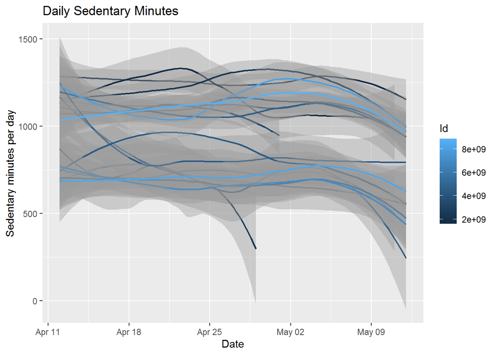

```r
ggplot(dailyActivitySubset, aes(x = ActivityDate, y = SedentaryMinutes, group = Id, color = Id)) + geom_smooth(size=0.8) +
  labs(title="Daily Sedentary Minutes", x="Date", y="Sedentary minutes per day")
```

This plot clearly shows a lot of variation, which obviously comes from the fact that every user leads a different life. Some might work physically demanding jobs and other people might work office jobs, which could be the reason for being Sedentary.

Although the smoothed lines do trend to go slightly down, it’s not enough to make assumptions at this point, and might even mean that my hypothesis was wrong. There’s also the issue that this small sample size is definitely not enough to get anything very significant out of it.

I need to look into the data in a different way in order to gain insights that might be useful for the marketing department.

Now I think it would be a good idea to plot a histogram with the sedentary minutes to see the distribution.

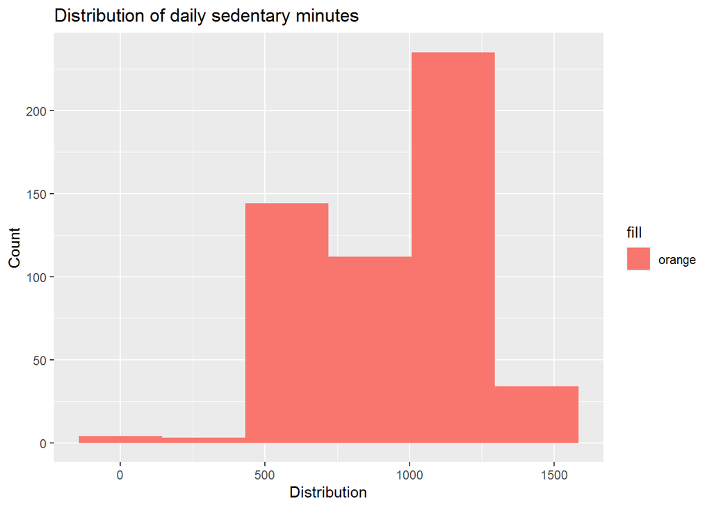

```r
ggplot(dailyActivitySubset, aes(x=SedentaryMinutes, fill='orange' )) + geom_histogram(bins = 6)  +
  labs(title="Distribution of daily sedentary minutes", x="Distribution", y="Count")
```

This plot does lend some insight into how active the people who submitted their data are. We can see a clear spike in the 1000-1250 minute bin, which equates to about 16-20 hours.

Knowing this, I can speculate that these highly sedentary users would be users who have jobs where they don’t really have to move around much throughout the day. I think that this information could be potentially very important as a metric.

There’s a lot of studies that suggest that being sedentary could lead to a lot of potential health issues down the line. Something that can be implemented would be a reminder in the form of a notification, for when the user has spent a lot of time sitting still. This could help improve the user’s health, which is a marketable feature.